# Análise de Regressão Linear Múltipla

Jefferson Brito

18-07-2022

# 1 Regressão linear para predição de preços de casas.

Para acessar as informações sobre o conjunto de dados clique [aqui](https://www.kaggle.com/datasets/tanyachawla412/house-prices).

## 1.1 Explicação das variáveis do conjunto de dados

- Avg. Area Income: Renda média da população da área onde a casa está localizada.
- House Age: Idade da casa em anos.
- Number of Rooms: Número de salas da casa.
- Number of Bedrooms: Número de quartos da casa.
- Area Population: População da área onde a casa está localizada.
- Price: Preço da casa.
- Address: Endereço da casa (será removida).

## 1.2 Carregando os pacotes que serão usados

```r
library(fBasics)
library(MASS)
library(lmtest)
library(car)
library(corrgram)
```

## 1.3 Carregando o conjunto de dados

```r
df = read.csv('House_price.csv') |> as.data.frame()
```

```r
head(df)
```

```
##   Avg..Area.Income House.Age Number.of.Rooms Number.of.Bedrooms Area.Population
## 1         79545.46  5.682861        7.009188               4.09        23086.80
## 2         79248.64  6.002900        6.730821               3.09        40173.07
## 3         61287.07  5.865890        8.512727               5.13        36882.16
## 4         63345.24  7.188236        5.586729               3.26        34310.24
## 5         59982.20  5.040555        7.839388               4.23        26354.11
## 6         80175.75  4.988408        6.104512               4.04        26748.43
##       Price
## 1 1059033.6
## 2 1505890.9
## 3 1058988.0
## 4 1260616.8
## 5  630943.5
## 6 1068138.1
```

## 1.4 Análise exploratória de dados

### 1.4.1 Algumas estatísticas desctitivas das variáveis

```r
basicStats(df)
```

```
##             Avg..Area.Income    House.Age Number.of.Rooms Number.of.Bedrooms
## nobs             4548.000000  4548.000000     4548.000000        4548.000000
## NAs                 0.000000     0.000000        0.000000           0.000000
## Minimum         17796.631190     2.644304        3.236194           2.000000
## Maximum        107701.748400     9.519088       10.759588           6.500000
## 1. Quartile     61485.150193     5.332187        6.299692           3.140000
## 3. Quartile     75820.741748     6.658368        7.665871           4.490000
## Mean            68611.700818     5.978918        6.987646           3.981693
## Median          68817.036575     5.960872        7.002245           4.050000
## Sum         312046015.319290 27192.121050    31779.813722       18108.740000
## SE Mean           158.461866     0.014693        0.014926           0.018253
## LCL Mean        68301.038574     5.950114        6.958384           3.945909
## UCL Mean        68922.363062     6.007723        7.016908           4.017477
## Variance    114201020.662387     0.981783        1.013217           1.515210
## Stdev           10686.487761     0.990850        1.006587           1.230939
## Skewness           -0.025256    -0.006478       -0.032819           0.373230
## Kurtosis            0.052880    -0.087926       -0.072680          -0.695154
##              Area.Population               Price
## nobs             4548.000000         4548.000000
## NAs                 0.000000            0.000000
## Minimum           172.610686        15938.657920
## Maximum         69592.040240      2469065.594000
## 1. Quartile     29423.163510       997775.110300
## 3. Quartile     42880.554642      1470615.595500
## Mean            36187.469334      1233915.795021
## Median          36215.560985      1234570.670000
## Sum         164580610.529009   5611849035.754700
## SE Mean           146.950730         5257.615341
## LCL Mean        35899.374507      1223608.314575
## UCL Mean        36475.564160      1244223.275467
## Variance     98211864.144565 125718176747.856415
## Stdev            9910.189915       354567.591226
## Skewness            0.041771            0.005249
## Kurtosis           -0.017711           -0.047178
```

### 1.4.2 Análise gráfica das variáveis

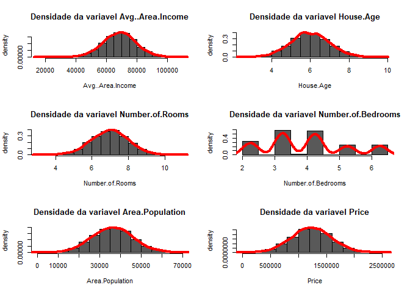

```r
par(mfrow=c(3, 2))

for (name in colnames(df)) {
  hist(df[[name]],freq=F,main=paste0("Densidade da variavel ",name),
       xlab = name,ylab = 'density',col='grey35')
  lines(density(df[[name]]),lwd=4,col='red')
}
```

Podemos notar que a variável `Number.of.Bedrooms` é a única variável que aparentemente não tende à distribuição normal.

### 1.4.3 Análise de correlação das variáveis

```r
cor(df)
```

```
##                    Avg..Area.Income    House.Age Number.of.Rooms
## Avg..Area.Income        1.000000000 -0.010143260    -0.006591518
## House.Age              -0.010143260  1.000000000     0.002683159
## Number.of.Rooms        -0.006591518  0.002683159     1.000000000
## Number.of.Bedrooms      0.024653775  0.017728397     0.464564938
## Area.Population        -0.007291989 -0.014899518    -0.003877480
## Price                   0.641381623  0.450133626     0.341572876
##                    Number.of.Bedrooms Area.Population     Price
## Avg..Area.Income           0.02465378    -0.007291989 0.6413816
## House.Age                  0.01772840    -0.014899518 0.4501336
## Number.of.Rooms            0.46456494    -0.003877480 0.3415729
## Number.of.Bedrooms         1.00000000    -0.018172432 0.1813707
## Area.Population           -0.01817243     1.000000000 0.4114532
## Price                      0.18137070     0.411453184 1.0000000
```

[figure not shown]

```r
corrgram(df,
         upper.panel=panel.cor,
         #upper.panel=panel.conf,
         cex.labels=1.5, cex=1.2)
```

Observando as correlações é possível identificar que existe uma correlação relevante entre as variáveis `Avg...Area.Income` e `Price`. É possivel identificar também que a nossa variável resposta `Price` tem correlação positiva com todas as variáveis explicativas.

## 1.5 Construção do modelo

Não foi detectado nenhum indício de que devemos retirar alguma variável para a contrução do modelo, portanto, construiremos o modelo com todas as variáveis do conjunto de dados.

```r
ml1 = lm(Price ~ ., data = df)
```

### 1.5.1 Análisando o modelo (ml1)

Nesse primero passo nós iremos analisar o R2 e testar algumas hipóteses, são elas:

Teste t:

h0: beta = 0

h1: beta != 0

Teste F:

h0: modelo ml1 = modelo nulo

h1: modelo ml2 != modelo nulo

```r
summary(ml1)
```

```
##
## Call:
## lm(formula = Price ~ ., data = df)
##
## Residuals:
##     Min      1Q  Median      3Q     Max
## -338141  -70192    -101   69104  347218
##
## Coefficients:
##                         Estimate    Std. Error  t value            Pr(>|t|)
## (Intercept)        -2639277.4236    17905.5777 -147.400 <0.0000000000000002 ***
## Avg..Area.Income         21.6097        0.1404  153.929 <0.0000000000000002 ***
## House.Age            165341.7291     1513.7249  109.228 <0.0000000000000002 ***
## Number.of.Rooms      121144.9059     1682.4891   72.003 <0.0000000000000002 ***
## Number.of.Bedrooms     1458.4804     1376.6499    1.059               0.289
## Area.Population          15.1882        0.1513  100.357 <0.0000000000000002 ***
## ---
## Signif. codes:  0 '***' 0.001 '**' 0.01 '*' 0.05 '.' 0.1 ' ' 1
##
## Residual standard error: 101100 on 4542 degrees of freedom
## Multiple R-squared:  0.9188, Adjusted R-squared:  0.9187
## F-statistic: 1.028e+04 on 5 and 4542 DF,  p-value: < 0.00000000000000022
```

Pelo teste t nós não rejeitamos h0 apenas para o parametro `Number.of.Bedrooms`, ou seja, ele contém o valor 0 no seu intervalo de confiança.

Pelo teste F nós rejeitamos h0, ou seja, o modelo proposto é diferente do modelo nulo.

O R2 e o R2-ajustado indicam que o modelo descreve bem a variação do preço das casas.

Vamos conferir o intervalo de confiança com 95% para os parâmetros.

```r
confint(ml1)
```

```
##                             2.5 %         97.5 %
## (Intercept)        -2674381.06553 -2604173.78175
## Avg..Area.Income         21.33449       21.88495
## House.Age            162374.09203   168309.36621
## Number.of.Rooms      117846.40892   124443.40284
## Number.of.Bedrooms    -1240.42305     4157.38388
## Area.Population          14.89154       15.48494
```

Como já imaginavamos, o intervalo de confiança para parâmetro `Number.of.Bedrooms` contém o valor 0.

### 1.5.2 Verificando os pressupostos para validação do modelo

#### 1.5.2.1 Independência dos dados

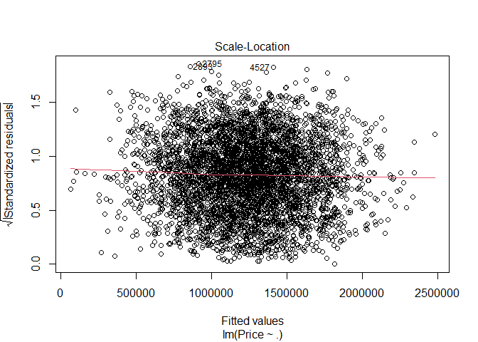

```r
plot(ml1, which = 3)
```

Nesse gráfico de valores ajustados vs raís quadrada dos resíduos padronizados podemos ver que os dados estão desperços em torno da linha vermelha e não há nenhuma tendencia visível, isso indica que os dados são independentes. Para confirmar iremos realizar o teste de Durbin-Watson, em que as hipoteses são:

h0: os valores dos resíduos do modelo são independentes;

h1: os resíduos são autocorrelacionados.

```r
durbinWatsonTest(ml1)
```

```
##  lag Autocorrelation D-W Statistic p-value
##    1   -0.0001884031      1.999709   0.998
##  Alternative hypothesis: rho != 0
```

Como o p-valor do teste foi maior do que os 5% de significancia, temos a não rejeição de h0. Portanto, a suposição de independencia dos dados foi atendida.

#### 1.5.2.2 Homocedasticidade dos resíduos

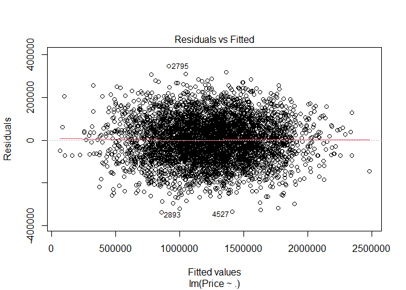

```r
plot(ml1, which = 1)
```

Neste gráfico seguimos praticamente a mesma linha de pensamento do anterior, sendo que aqui os dados tem que estar dispersos ao redor da média (zero, já que tem que seguir normalidade com a média igual a 0) e não podem apresentar nenhum tipo de tendencia.

Para confirmar se os resíduos são mesmo homocedasticos iremos realizar o teste de Breusch-Pagan, que tem como hipóteses:

h0: há homocedasticidade nos dados;

h1: há heterocedasticidade nos dados.

```r
bptest(ml1)
```

```
##
##  studentized Breusch-Pagan test
##
## data:  ml1
## BP = 5.941, df = 5, p-value = 0.312
```

Como o valor-p 0,312 foi maior do que 5% de significância, temos a não rejeição de h0. Assim, a suposição de homocedasticidade foi atendida.

#### 1.5.2.3 Normalidade dos resíduos

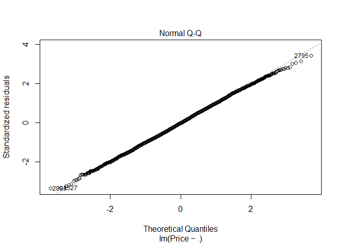

```r
plot(ml1, which = 2)
```

Como quase todos os dados estão em cima da linha, temos indícios que levam a acreditar que os resíduos seguem normalidade. Para confirmar isso, construirei um outro grafico e realizarei o teste de Shapiro-Wilk, que tem como hipoteses:

h0: a distribuição Normal modela adequadamente os resíduos do modelo;

h1: a distribuição Normal não modela adequadamente os resíduos do modelo.

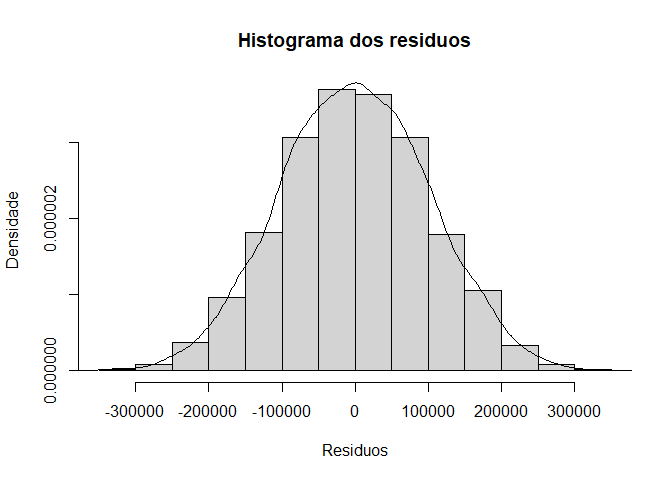

```r
hist(ml1$residuals, probability = T, xlab = "Residuos", ylab = "Densidade",
     main = "Histograma dos residuos")
lines(density(ml1$residuals))
```

```r
shapiro.test(ml1$residuals)
```

```
##
##  Shapiro-Wilk normality test
##
## data:  ml1$residuals
## W = 0.99949, p-value = 0.2657
```

Como o p-valor 0,2657 foi maior do que 5% de significancia, temos a não rejeição de h0. Logo, a suposição de normalidade foi atendida.

Então, de acordo com os gráficos e com o teste de Shapiro-Wilk temos que os resíduos são normalmente distribuidos.

A homocedasticidade dos resíduos também pode ser comprovada quando os resíduos seguem a distribuição normal.

#### 1.5.2.4 Multicolinearidade

A multicolinearidade pode ser verificada com o `vif()`, que mede o quanto a variância de um coeficiente de regressão estimado aumenta se seus preditores estão correlacionados. Se todos os VIFs forem 1, não há multicolinearidade, mas se alguns VIFs forem maiores do que 1, os preditores estão correlacionados.

```r
vif(ml1)
```

```
##   Avg..Area.Income          House.Age    Number.of.Rooms Number.of.Bedrooms
##           1.001187           1.000683           1.275833           1.277340
##    Area.Population
##           1.000616
```

Este teste identificou uma pequena correlação entre as variáveis `Number.of.Bedrooms` e `Number.of.Rooms`, que já haviamos detectado na análise de correlção.

Este modelo, atende todos os pressupostos, mas possui um parâmetro não significante. Portanto, irei realizar o StepWise nesse modelo para ver se ele indica algum modelo melhor.

### 1.5.3 StepWise

```r
step(ml1, direction = "both")
```

```
## Start:  AIC=104827.4
## Price ~ Avg..Area.Income + House.Age + Number.of.Rooms + Number.of.Bedrooms +
##     Area.Population
##
##                      Df       Sum of Sq             RSS    AIC
## - Number.of.Bedrooms  1     11473406786  46440047301338 104827
## <none>                                   46428573894552 104827
## - Number.of.Rooms     1  52996114209002  99424688103554 108289
## - Area.Population     1 102952334554362 149380908448914 110140
## - House.Age           1 121957709346755 168386283241307 110685
## - Avg..Area.Income    1 242202217792954 288630791687506 113136
##
## Step:  AIC=104826.6
## Price ~ Avg..Area.Income + House.Age + Number.of.Rooms + Area.Population
##
##                      Df       Sum of Sq             RSS    AIC
## <none>                                   46440047301338 104827
## + Number.of.Bedrooms  1     11473406786  46428573894552 104827
## - Number.of.Rooms     1  68537929141197 114977976442535 108948
## - Area.Population     1 102946550757089 149386598058427 110138
## - House.Age           1 122044433412695 168484480714033 110685
## - Avg..Area.Income    1 242545400457275 288985447758613 113139
```

```
##
## Call:
## lm(formula = Price ~ Avg..Area.Income + House.Age + Number.of.Rooms +
##     Area.Population, data = df)
##
## Coefficients:
##      (Intercept)  Avg..Area.Income         House.Age   Number.of.Rooms
##      -2639655.67             21.61         165371.67         121973.62
##  Area.Population
##            15.19
```

O step retornou que o modelo sem o parâmetro não significativo seria uma melhor opção. Portanto, iremos construir um novo modelo sem esse parâmetro.

## 1.6 Construção do segundo modelo

```r
ml2 = lm(Price ~ Avg..Area.Income + House.Age + Number.of.Rooms + Area.Population, data = df)
```

### 1.6.1 Analisando o segundo modelo (ml2)

```r
summary(ml2)
```

```
##
## Call:
## lm(formula = Price ~ Avg..Area.Income + House.Age + Number.of.Rooms +
##     Area.Population, data = df)
##
## Residuals:
##     Min      1Q  Median      3Q     Max
## -339350  -70321    -126   69246  347378
##
## Coefficients:
##                       Estimate    Std. Error t value            Pr(>|t|)
## (Intercept)      -2639655.6739    17902.2591 -147.45 <0.0000000000000002 ***
## Avg..Area.Income       21.6144        0.1403  154.04 <0.0000000000000002 ***
## House.Age          165371.6724     1513.4814  109.27 <0.0000000000000002 ***
## Number.of.Rooms    121973.6187     1489.6196   81.88 <0.0000000000000002 ***
## Area.Population        15.1854        0.1513  100.35 <0.0000000000000002 ***
## ---
## Signif. codes:  0 '***' 0.001 '**' 0.01 '*' 0.05 '.' 0.1 ' ' 1
##
## Residual standard error: 101100 on 4543 degrees of freedom
## Multiple R-squared:  0.9188, Adjusted R-squared:  0.9187
## F-statistic: 1.284e+04 on 4 and 4543 DF,  p-value: < 0.00000000000000022
```

Testes realizados:

Teste t:

h0: beta = 0

h1: beta != 0

Pelo teste t nós rejeitamos h0 para todos os parametros, ou seja, todos os parâmetros são significativos para o modelo predizer o preço das casas, pois não possuem o valor 0 em seu intervalo de confiança.

Teste F:

h0: modelo ml2 = modelo nulo

h1: modelo ml2 != modelo nulo

Pelo teste F nós rejeitamos h0, portanto, o segundo modelo também é diferente do modelo nulo.

Já o R2 e o R2-ajustado indicam que o modelo descreve bem a variação do preço das casas.

Vamos verificar o intervalo de confiança a 95% para os parâmetros]

```r
confint(ml2)
```

```
##                           2.5 %         97.5 %
## (Intercept)      -2674752.80755 -2604558.54016
## Avg..Area.Income       21.33929       21.88948
## House.Age          162404.51288   168338.83200
## Number.of.Rooms    119053.23992   124893.99756
## Area.Population        14.88870       15.48202
```

Como dito anteriormente, os parâmetros não possuem o valor 0 em seus intervalos de confiança.

### 1.6.2 Verificando os presupostos do modelo

#### 1.6.2.1 Independência dos dados

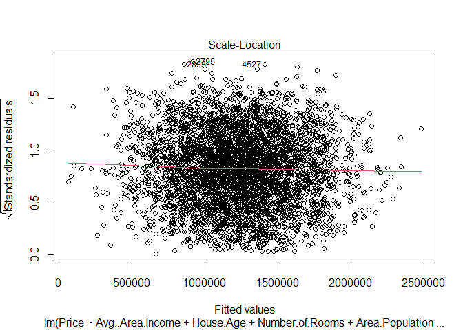

```r
plot(ml2, which = 3)
```

Teste de Durbin-Watson:

h0: os valores dos resíduos do modelo são independentes;

h1: os resíduos são autocorrelacionados.

```r
durbinWatsonTest(ml2)
```

```
##  lag Autocorrelation D-W Statistic p-value
##    1   -0.0004825349        2.0003   0.962
##  Alternative hypothesis: rho != 0
```

Como o p-valor do teste foi maior do que os 5% de significancia, temos a não rejeição de h0. Portanto, a suposição de independencia dos dados foi atendida.

#### 1.6.2.2 Homocedasticidade dos resíduos

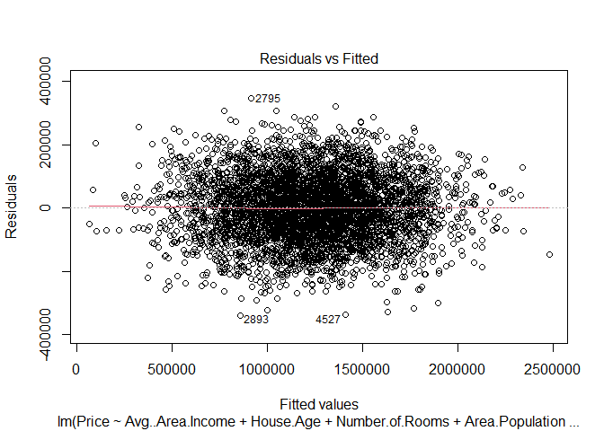

```r
plot(ml2, which = 1)
```

Teste de Breusch-Pagan:

h0: ha homocedasticidade nos dados;

h1: ha heterocedasticidade nos dados.

```r
bptest(ml2)
```

```
##
##  studentized Breusch-Pagan test
##
## data:  ml2
## BP = 5.8309, df = 4, p-value = 0.2121
```

Como o valor-p 0,2121 foi maior do que 5% de significância, temos a não rejeição de h0. Assim, a suposição de homocedasticidade foi atendida.

#### 1.6.2.3 Normalidade dos resíduos

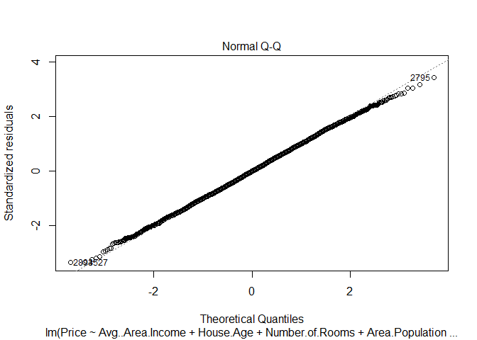

```r
plot(ml2, which = 2)
```

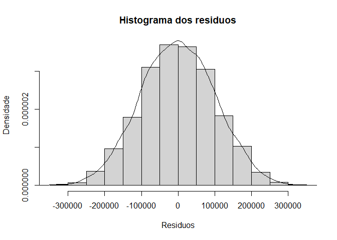

```r
hist(ml2$residuals, probability = T, xlab = "Residuos", ylab = "Densidade",
     main = "Histograma dos residuos")
lines(density(ml2$residuals))
```

Teste de Shapiro-Wilk:

h0: a distribuição Normal modela adequadamente os resíduos do modelo;

h1: a distribuição Normal não modela adequadamente os resíduos do modelo.

```r
shapiro.test(ml2$residuals)
```

```
##
##  Shapiro-Wilk normality test
##
## data:  ml2$residuals
## W = 0.9995, p-value = 0.2911
```

Como o p-valor 0,2911 foi maior do que 5% de significancia, temos a não rejeição de h0. Logo, a suposição de normalidade foi atendida.

#### 1.6.2.4 Multicolinearidade

```r
vif(ml2)
```

```
## Avg..Area.Income        House.Age  Number.of.Rooms  Area.Population
##         1.000202         1.000334         1.000065         1.000293
```

Como todos os VIF’s foram praticamente iguais a 1, temos que não há multicolinearidade.

Tendo em vista que todos os pressupostos foram atendidos, podemos então dizer que o ml2 é um bom modelo para predição do preço de casas.

## 1.7 Comparando os dois modelos

Como os dois modelos tiveram os pressupostos atendidos, então podemos compara-los, tendo como finalidade descobrir se realmente houve uma grande diferença no desempenhos dos mesmos.

### 1.7.1 Comparando via R2 ajustado

```r
modelos = c('Modelo 1','Modelo 2')
r2_ajustados = c(summary(ml1)$adj.r.squared,summary(ml2)$adj.r.squared)
tabela = data.frame(modelos,r2_ajustados) |> print()
```

```
##    modelos r2_ajustados
## 1 Modelo 1    0.9186907
## 2 Modelo 2    0.9186885
```

O R2 ajustado dos dois modelos apresentam praticamente o mesmo valor. Portanto, há indícios de que os dois modelos descrevem bem a variação do preço das casas.

### 1.7.2 Comparando via ANOVA

```r
anova(ml1, ml2)
```

```
## Analysis of Variance Table
##
## Model 1: Price ~ Avg..Area.Income + House.Age + Number.of.Rooms + Number.of.Bedrooms +
##     Area.Population
## Model 2: Price ~ Avg..Area.Income + House.Age + Number.of.Rooms + Area.Population
##   Res.Df            RSS Df    Sum of Sq      F Pr(>F)
## 1   4542 46428573894552
## 2   4543 46440047301338 -1 -11473406786 1.1224 0.2895
```

O teste F para analise de variancia mostra que não existe diferença significativa entre os modelos analisados, ou seja, ambos os modelos descrevem da mesma forma a variabilidade dos dados. O RSS (soma de quadrado dos resíduos) de ambos também é praticamente o mesmo.

### 1.7.3 AIC

O **critério de informação de Akaike** (AIC) é uma métrica que mensura a qualidade de um modelo estatístico visando também a sua simplicidade. Fornece, portanto, uma métrica para comparação e seleção de modelos, em que menores valores de AIC representam uma maior qualidade e simplicidade, segundo este critério.

```r
AIC(ml1, ml2)
```

```
##     df      AIC
## ml1  7 117736.1
## ml2  6 117735.2
```

Também no critério de Akaike os dois modelos possuem praticamente o mesmo valor, isso significa dizer que ambos os modelos possuem a mesma qualidade e simplicidade.

## 1.8 Escolha do modelo

De acordo com o método stepwise e com as métricas utilizadas para seleçãoo do modelo (R2 ajustado,AIC e ANOVA), o modelo escolhido como ideal para esses dados será o modelo 2 (ml2) ao qual possui todos os parâmetros significantes diante do teste t, rejeitando a hipótese de que os parâmetros são iguais a 0 (h0: beta = 0), possui um R2 muito bom, e além disso, o modelo também tem um valor de p significante para o teste F do modelo. Isso significa que o modelo desenvolvido é diferente do modelo nulo, ao qual seria o modelo que possui apenas o intercepto como parâmetro, ou seja, os valores da variável resposta previstos pelo modelo seriam iguais a média (h0: ml2 = modelo nulo). O que desclassifica o modelo 1 (ml1) é apenas o fato de ele possuir um parâmetro não significante.

## 1.9 Exemplo

```r
ml2$coefficients
```

```
##      (Intercept) Avg..Area.Income        House.Age  Number.of.Rooms
##   -2639655.67386         21.61438     165371.67244     121973.61874
##  Area.Population
##         15.18536
```

Tendo em vista que o nossos parâmetros são de difícil interpretação (por conta do alto valor negativo do intercepto), iremos criar um exemplo prático e analisaremos o resultado.

Para esse exemplo usaremos uma casa desse conjunto de dados que possui:

- Renda média anual da área (`Avg..Area.Income`) de aproximadamente 60000 (sessenta mil) dólares;
- 5 anos de Idade da casa (`House.Age`);
- 8 cômodos (`Number.of.Rooms`);
- E aproximadamente 27809 (vinte e sete mil oitossentos e nove) pessoas que moram na área (`Area.Population`).

No nosso conjunto de dados essa casa custa aproximadamente 895737 (oitossentos e noventa e cinco mil setessentos e trinta e sete) dólares.

```r
df[25,]
```

```
##    Avg..Area.Income House.Age Number.of.Rooms Number.of.Bedrooms
## 25         59748.86   5.33934        7.748682               4.23
##    Area.Population    Price
## 25        27809.99 895737.1
```

Vamos então realizar essa predição:

```r
attach(df)
newdata = data.frame(Avg..Area.Income = 60000, House.Age = 5, Number.of.Rooms = 8, Area.Population = 27809)
predict(ml2, newdata = newdata)
```

```
##        1
## 882144.3
```

Nosso modelo fez uma predição decente do preço dessa casa, levando a crêr que realmente seja um bom modelo.

## 1.10 Conclusão

O nosso segundo modelo (ml2) teve todos os pressupostos atendidos e parece ser um bom modelo para predição de preços de casas.

Para trabalhos futuros eu indico a padronização dos dados, afim de uma diminuição da variância em algumas variáveis.

Por fim, agradeço a todos vocês!

Obrigado!